# LEE_CID: 01247436

Seongmin Lee

## Train, Test dataset split

To find out the best models to predict the lettuce demand, the dataset is divided into two parts, the testset and the trainset. The testset was allocated with the fourteen datapoints in that we are pursuing the fourteen days forecast. And the rest of the data point turned into the trainset. In addition, missing values labled as ‘0’ and outliers at the beginning have been removed to make the dataset unbiased in a continuous time series scale.

```r
# New.York.1..ID.12631
data1 <- data[data$New.York.1..ID.12631. > 0, 2]
ny1 <- ts(data1, frequency = 7)
ny1_train <- ts(data1[1:(length(ny1) - 14)], frequency = 7)
ny1_test <- ts(data1[(length(ny1) - 13):length(ny1)], frequency = 7, start = c(13, 6))

#California.1..ID.46673
data2 <- data[data$California.1..ID.46673. > 0, 3]
ca1 <- ts(data2, frequency = 7)
ca1_train <- ts(data2[1:(length(ca1) - 14)], frequency = 7)
ca1_test <- ts(data2[(length(ca1) - 13):length(ca1)], frequency = 7, start = c(13, 6))

#New.York.2..ID.20974
data3 <- data[16:nrow(data), 4]
ny2 <- ts(data3, frequency = 7)
ny2_train <- ts(data3[1:(length(ny2) - 14)], frequency = 7)
ny2_test <- ts(data3[(length(ny2) - 13):length(ny2)], frequency = 7, start = c(11, 5))

#California.2..ID.4904
data4 <- data[9:nrow(data), 5]
ca2 <- ts(data4, frequency = 7)
ca2_train <- ts(data4[1:(length(ca2) - 14)], frequency = 7)
ca2_test <- ts(data4[(length(ca2) - 13):length(ca2)], frequency = 7, start = c(12, 5))
```

# 1. Store in New York 1 (ID: 12631)

First of all, we need to observe the time series data by visualising in graphs as below. Based on the top line chart depicting the ny1_12631 trainset, it is hard to point out that there is certain trend or seasonal significance.

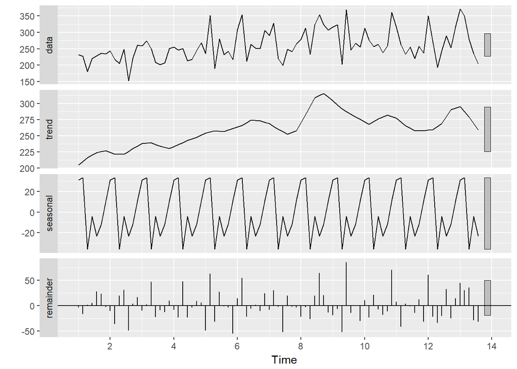

```r
ny1_train %>% stl(s.window = "period") %>% autoplot
```

## Q1. Holt-Winters Analysis

To perform the Holt-winters analysis, we need to use both $HoltWinters$ and $ets$ functions to find out a form of the systematic components by minimising the forecast errors. As a result of $ets$ on the ny1 trainset, We conclude the model of $ETS(M, N, M)$, which indicates the multiplicative error type, no trend, and the multiplicative seasonal type. And the Holt-winter model have exponential smoothing with trend and additive seasonal component. The Holt-winters fitted values and ETS fitted values are colored as red and blue, repectively.

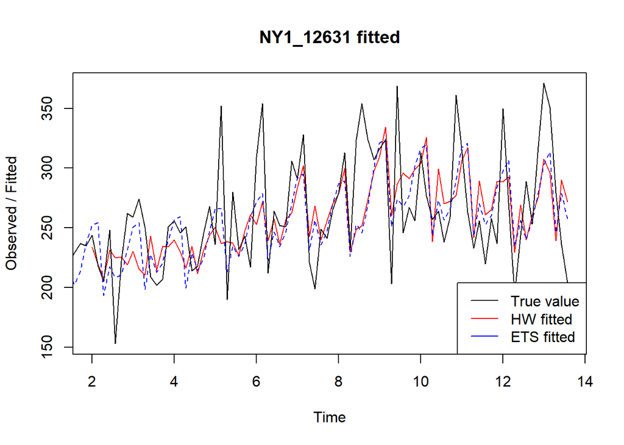

```r
ny1_train_ets <- ets(ny1_train, model = "ZZZ") #ETS(M,N,M)
ny1_train_HW <- HoltWinters(ny1_train)

plot(ny1_train_HW, main = "NY1_12631 fitted")
lines(fitted(ny1_train_ets), col = "blue", lty = 2)
legend("bottomright",c("True value", "HW fitted", "ETS fitted"), lty = 1, col = c("black","red", "blue"))
```

When it comes to the forecast in the fourteen days, both of the models seems very similiar on the plot. However, the predictions are somewhat different from the the true values. To be specific, the forecast did not represent the peak seasons well.

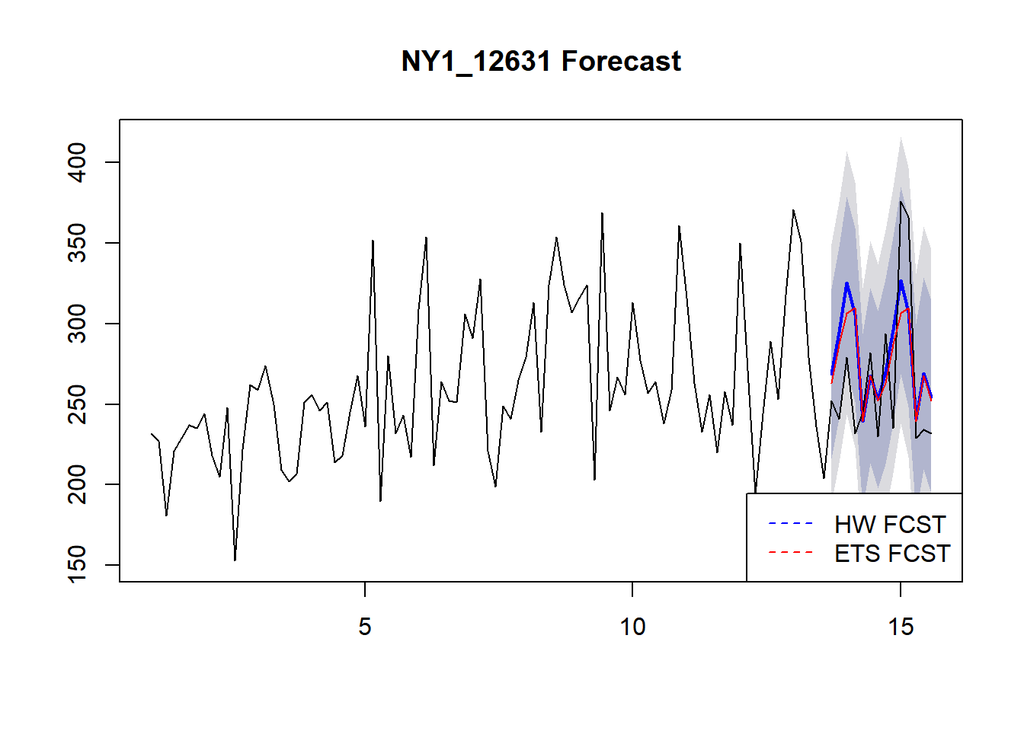

```r
ny1_train_ets_fcst <- forecast(ny1_train_ets, h = 14)
ny1_train_HW_fcst <- forecast(ny1_train_HW, h = 14)

plot(ny1_train_HW_fcst, main = "NY1_12631 Forecast")
lines(ny1)
lines(ny1_train_ets_fcst$mean, col = "red")
legend("bottomright",c("HW FCST", "ETS FCST"), lty = 2, col = c("blue","red"))
```

## Q2. ARIMA Analysis

Based on the figure of ACF and PACF, we can assume the moving avarge1(MA1) as a candicate model because the the values at the PACF chart decreases exponentially, and there is one spike at one in the ACF graph as below.

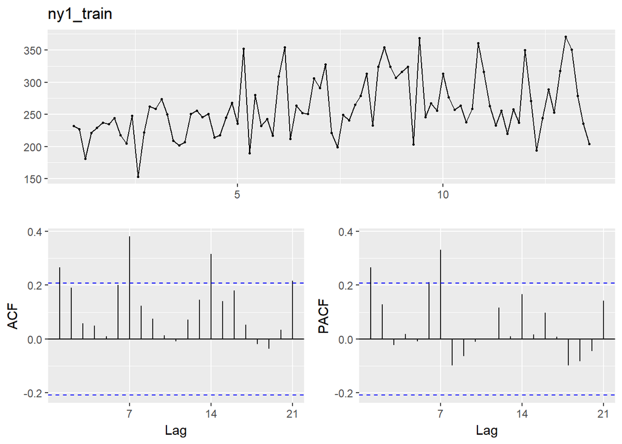

```r
ggtsdisplay(ny1_train)
```

```r
adf.test(ny1_train)
```

```
##
##  Augmented Dickey-Fuller Test
##
## data:  ny1_train
## Dickey-Fuller = -4.8181, Lag order = 4, p-value = 0.01
## alternative hypothesis: stationary
```

```r
pp.test(ny1_train)
```

```
##
##  Phillips-Perron Unit Root Test
##
## data:  ny1_train
## Dickey-Fuller Z(alpha) = -75.753, Truncation lag parameter = 3,
## p-value = 0.01
## alternative hypothesis: stationary
```

```r
kpss.test(ny1_train)
```

```
##
##  KPSS Test for Level Stationarity
##
## data:  ny1_train
## KPSS Level = 1.0498, Truncation lag parameter = 2, p-value = 0.01
```

The $ndiffs$ funtions also points out that we need to take the first order of difference in terms of non-seasonality. After differecing, the $ndiffs$ function’s output is 0, which means we do not need any more difference for stataionarity.

```r
ndiffs(ny1_train)
```

```
## [1] 1
```

```r
ny1_train_diff <- diff(x = ny1_train, differences = 1)
ndiffs(ny1_train_diff)
```

```
## [1] 0
```

The p-value of the ADF and PP test is now smaller than 0.01 which rejects the null hypothesis of non-staionarity. And the kpss test points out the p-value greater than 0.1, which means we cannot reject the H0 of staionarity. Therefore, the time series data after taking the first order differece turned out to be stationary.

```r
adf.test(ny1_train_diff)
```

```
##
##  Augmented Dickey-Fuller Test
##
## data:  ny1_train_diff
## Dickey-Fuller = -7.178, Lag order = 4, p-value = 0.01
## alternative hypothesis: stationary
```

```r
pp.test(ny1_train_diff)
```

```
##
##  Phillips-Perron Unit Root Test
##
## data:  ny1_train_diff
## Dickey-Fuller Z(alpha) = -112.24, Truncation lag parameter = 3,
## p-value = 0.01
## alternative hypothesis: stationary
```

```r
kpss.test(ny1_train_diff)
```

```
##
##  KPSS Test for Level Stationarity
##
## data:  ny1_train_diff
## KPSS Level = 0.036307, Truncation lag parameter = 2, p-value = 0.1
```

Despite the non-seasonality difference, we can see some spikes on 7, 14, and 21 periodically, which might demonstrates that the dataset is not stationary in terms of seasonality as below.

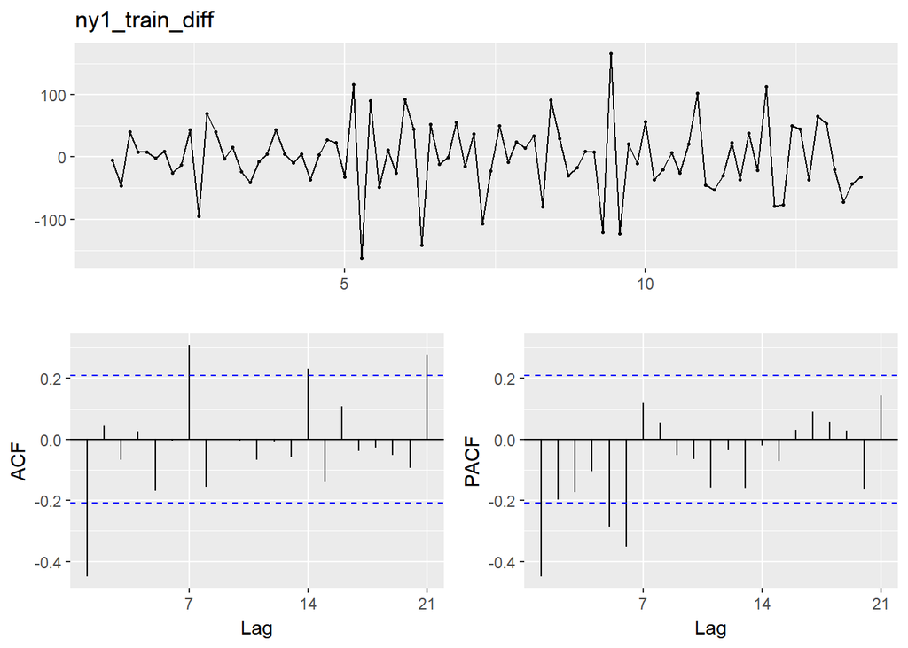

```r
ggtsdisplay(ny1_train_diff)
```

As depicted below, the third graph from the top shows that there might be seasonal factors in the dataset by showing the shorter gray bar which indicates the higher probability of significance.

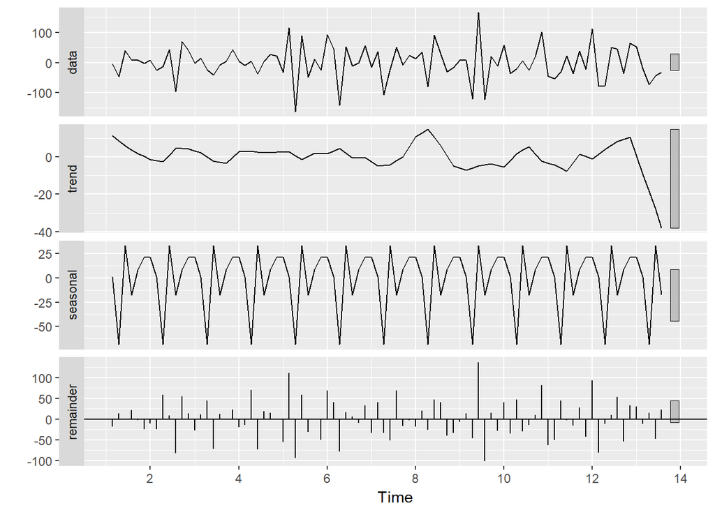

```r
ny1_train_diff %>% stl(s.window = "period") %>% autoplot
```

However, the result from the $OCSB$ test points out we do not need to take a difference in seasonality as below.

```r
nsdiffs(ny1_train, m = 7, test = "ocsb", max.D = 1)
```

```
## [1] 0
```

However, to find out the best predicting model, we need to build multiple models by running auto.arima with and without the seasonal difference separately as follows.

```r
auto.arima(ny1_train, d= 1, D = 1, trace = TRUE, ic = 'bic')
```

```
##
##  ARIMA(2,1,2)(1,1,1)[7]                    : Inf
##  ARIMA(0,1,0)(0,1,0)[7]                    : 916.8701
##  ARIMA(1,1,0)(1,1,0)[7]                    : 881.0462
##  ARIMA(0,1,1)(0,1,1)[7]                    : 848.8592
##  ARIMA(0,1,1)(1,1,1)[7]                    : Inf
##  ARIMA(0,1,1)(0,1,0)[7]                    : Inf
##  ARIMA(0,1,1)(0,1,2)[7]                    : Inf
##  ARIMA(0,1,1)(1,1,2)[7]                    : Inf
##  ARIMA(1,1,1)(0,1,1)[7]                    : 853.1214
##  ARIMA(0,1,0)(0,1,1)[7]                    : Inf
##  ARIMA(0,1,2)(0,1,1)[7]                    : 853.1366
##  ARIMA(1,1,2)(0,1,1)[7]                    : Inf
##
##  Best model: ARIMA(0,1,1)(0,1,1)[7]
```

```
## Series: ny1_train
## ARIMA(0,1,1)(0,1,1)[7]
##
## Coefficients:
##           ma1     sma1
##       -0.8845  -0.9178
## s.e.   0.0670   0.2545
##
## sigma^2 estimated as 1517:  log likelihood=-417.84
## AIC=841.68   AICc=841.99   BIC=848.86
```

```r
auto.arima(ny1_train, trace = TRUE, ic = 'bic')
```

```
##
##  ARIMA(2,1,2)(1,0,1)[7] with drift         : Inf
##  ARIMA(0,1,0)           with drift         : 969.3028
##  ARIMA(1,1,0)(1,0,0)[7] with drift         : 944.0507
##  ARIMA(0,1,1)(0,0,1)[7] with drift         : Inf
##  ARIMA(0,1,0)                              : 964.8282
##  ARIMA(1,1,0)           with drift         : 954.0502
##  ARIMA(1,1,0)(2,0,0)[7] with drift         : 947.1224
##  ARIMA(1,1,0)(1,0,1)[7] with drift         : Inf
##  ARIMA(1,1,0)(2,0,1)[7] with drift         : Inf
##  ARIMA(0,1,0)(1,0,0)[7] with drift         : 964.9701
##  ARIMA(2,1,0)(1,0,0)[7] with drift         : 945.5444
##  ARIMA(1,1,1)(1,0,0)[7] with drift         : Inf
##  ARIMA(2,1,1)(1,0,0)[7] with drift         : Inf
##  ARIMA(1,1,0)(1,0,0)[7]                    : 939.584
##  ARIMA(1,1,0)                              : 949.5754
##  ARIMA(1,1,0)(2,0,0)[7]                    : 942.6512
##  ARIMA(1,1,0)(1,0,1)[7]                    : Inf
##  ARIMA(1,1,0)(2,0,1)[7]                    : Inf
##  ARIMA(0,1,0)(1,0,0)[7]                    : 960.4992
##  ARIMA(2,1,0)(1,0,0)[7]                    : 941.071
##  ARIMA(1,1,1)(1,0,0)[7]                    : 926.3768
##  ARIMA(2,1,2)(1,0,0)[7]                    : 931.8412
##  ARIMA(1,1,1)                              : 932.1089
##  ARIMA(1,1,1)(2,0,0)[7]                    : 926.1147
##  ARIMA(1,1,1)(2,0,1)[7]                    : 930.6548
##  ARIMA(0,1,1)(2,0,0)[7]                    : 922.2888
##  ARIMA(0,1,0)(2,0,0)[7]                    : 962.6261
##  ARIMA(0,1,2)(2,0,0)[7]                    : 926.2171
##  ARIMA(1,1,2)(2,0,0)[7]                    : Inf
##  ARIMA(0,1,1)(2,0,0)[7] with drift         : Inf
##  ARIMA(0,1,1)(1,0,0)[7]                    : 922.9761
##  ARIMA(0,1,1)(2,0,1)[7]                    : Inf
##
##  Best model: ARIMA(0,1,1)(2,0,0)[7]
```

```
## Series: ny1_train
## ARIMA(0,1,1)(2,0,0)[7]
##
## Coefficients:
##           ma1    sar1    sar2
##       -0.9282  0.2638  0.2617
## s.e.   0.0436  0.1074  0.1120
##
## sigma^2 estimated as 1695:  log likelihood=-452.19
## AIC=912.38   AICc=912.86   BIC=922.29
```

Based on the information criteriors, there are four cadidate ARIMA models as below. The 1 and 2 models are the ones with the seasonal and non-seaonal difference. The other two models are with the only non-seaonal difference.

1. ARIMA(p=0,d=1,q=1)(P=0,D=1,Q=1)[7]: 848.8592
2. ARIMA( 1, 1, 1)( 0, 1, 1)[7]: 853.1214
3. ARIMA( 0, 1, 1)( 2, 0, 0)[7]: 922.2888
4. ARIMA( 0, 1, 1)( 1, 0, 0)[7]: 922.9761

With the parameters p, d, q, P, D, and Q above, we can build the estimated models as below. Moreover, we are now able to come up with the fourteen days forecast to choose the best model on accuracy.

```r
ny1_m1 <- Arima(ny1_train, order = c(0, 1, 1),
                seasonal = list(order = c(0, 1, 1), period = 7),
                include.drift = FALSE)
ny1_m1_FCST <- forecast(ny1_m1, h = 14)

ny1_m2 <- Arima(ny1_train, order = c(1, 1, 1),
                seasonal = list(order = c(0, 1, 1), period = 7),
                include.drift = FALSE)
ny1_m2_FCST <- forecast(ny1_m2, h = 14)

ny1_m3 <- Arima(ny1_train, order = c(0, 1, 1),
                seasonal = list(order = c(2, 0, 0), period = 7),
                include.drift = FALSE)
ny1_m3_FCST <- forecast(ny1_m3, h = 14)

ny1_m4 <- Arima(ny1_train, order = c(0, 1, 1),
                seasonal = list(order = c(1, 0, 0), period = 7),
                include.drift = FALSE)
ny1_m4_FCST <- forecast(ny1_m4, h = 14)
```

The next step is to check if the residuals of each model follow the white noise process by $Box.test$, which means the residuals are independent from the time series data. The null hypothesis of the $Box.test$ is the time series residuals satisfy the white noise process. All of the models’ p-values are above 0.05, which cannot reject the null hypothesis of following the white noise process. Therefore, the four models are valid to forecast in the time series.

```r
Box.test(ny1_m1$residuals, lag = 20, type = "Ljung-Box", fitdf = 4)
```

```
##
##  Box-Ljung test
##
## data:  ny1_m1$residuals
## X-squared = 17.165, df = 16, p-value = 0.375
```

```r
Box.test(ny1_m2$residuals, lag = 20, type = "Ljung-Box", fitdf = 4)
```

```
##
##  Box-Ljung test
##
## data:  ny1_m2$residuals
## X-squared = 16.242, df = 16, p-value = 0.4362
```

```r
Box.test(ny1_m3$residuals, lag = 20, type = "Ljung-Box", fitdf = 4)
```

```
##
##  Box-Ljung test
##
## data:  ny1_m3$residuals
## X-squared = 13.964, df = 16, p-value = 0.6014
```

```r
Box.test(ny1_m4$residuals, lag = 20, type = "Ljung-Box", fitdf = 4)
```

```
##
##  Box-Ljung test
##
## data:  ny1_m4$residuals
## X-squared = 22.298, df = 16, p-value = 0.1338
```

# 2. Store in California 1 (ID: 46673)

When it comes to the store labeld as 46673 in CA, there is a strong seaonal factor rather than a trend based on the below third plots from the top.

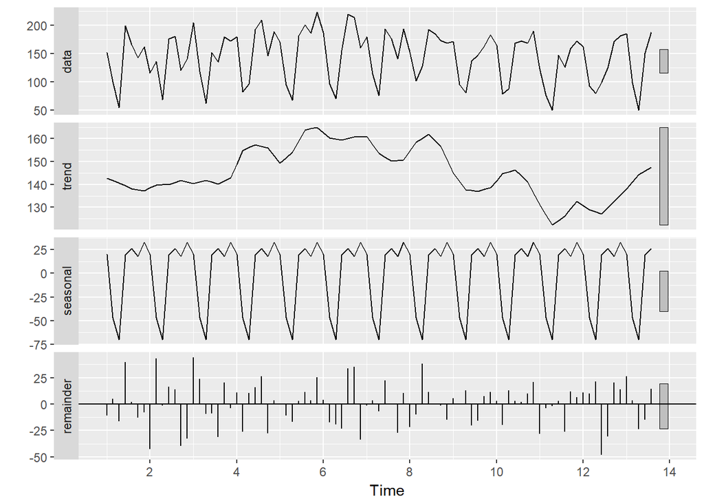

```r
ca1_train %>% stl(s.window = "period") %>% autoplot
```

## Q1. Holt Winter Analysis

From a result of $ets$ on the ca1 trainset, we conclude the $ETS(A, N, A)$, which demonstrates the additive error type, no trend, and the additive seaonal type. And the Holt winter model has exponential smoothing with trend and additive seasonal component. It seems that both the $ETS$ and $Holt Winters$ models fits well in the trainset as depicted.

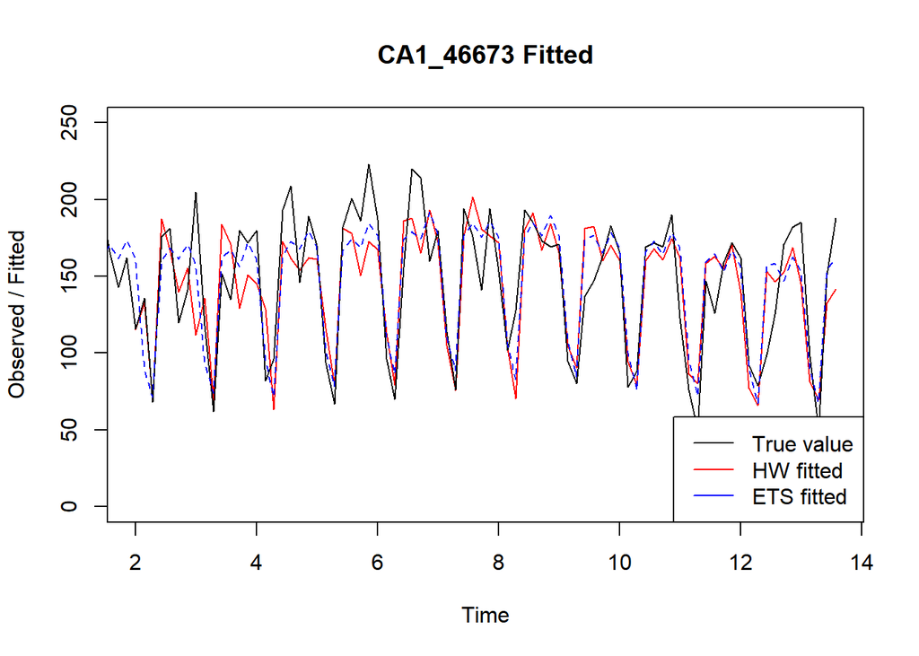

```r
plot(ca1_train_HW, ylim = c(0, 250), main = "CA1_46673 Fitted")
lines(fitted(ca1_train_ets), col = "blue", lty = 2)
legend("bottomright",c("True value", "HW fitted", "ETS fitted"), lty = 1, col = c("black","red", "blue"))
```

When it comes to the prediction in the fourteen days as depicted below, the two models cannot represent the spikes. However, if we consider the spikes in the fourteen days as unpredictable outlier, then the both prediction from the two models are working well.

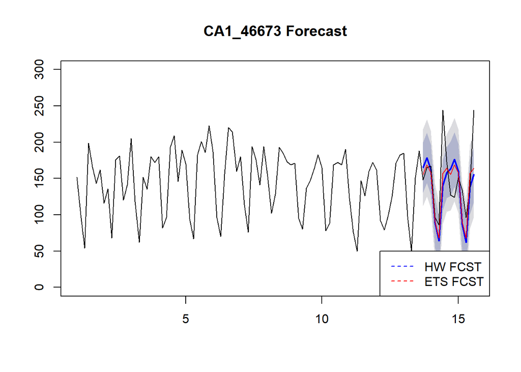

```r
ca1_train_ets_fcst <- forecast(ca1_train_ets, h = 14)
ca1_train_HW_fcst <- forecast(ca1_train_HW, h = 14)

plot(ca1_train_HW_fcst, ylim = c(0, 300), main = "CA1_46673 Forecast")
lines(ca1)
lines(ca1_train_ets_fcst$mean, col = "red")
legend("bottomright",c("HW FCST", "ETS FCST"), lty = 2, col = c("blue","red"))
```

## Q2. ARIMA Analysis

It is hard to argue what arima model will be based on the below ACF and PACF graphs. However, on every 7, 14, and 21 day, there is a spike observed. Therefore, we can assume that there might be a seasonal factor in the time series data as observed in the $ETS$ and $HW$ modeling.

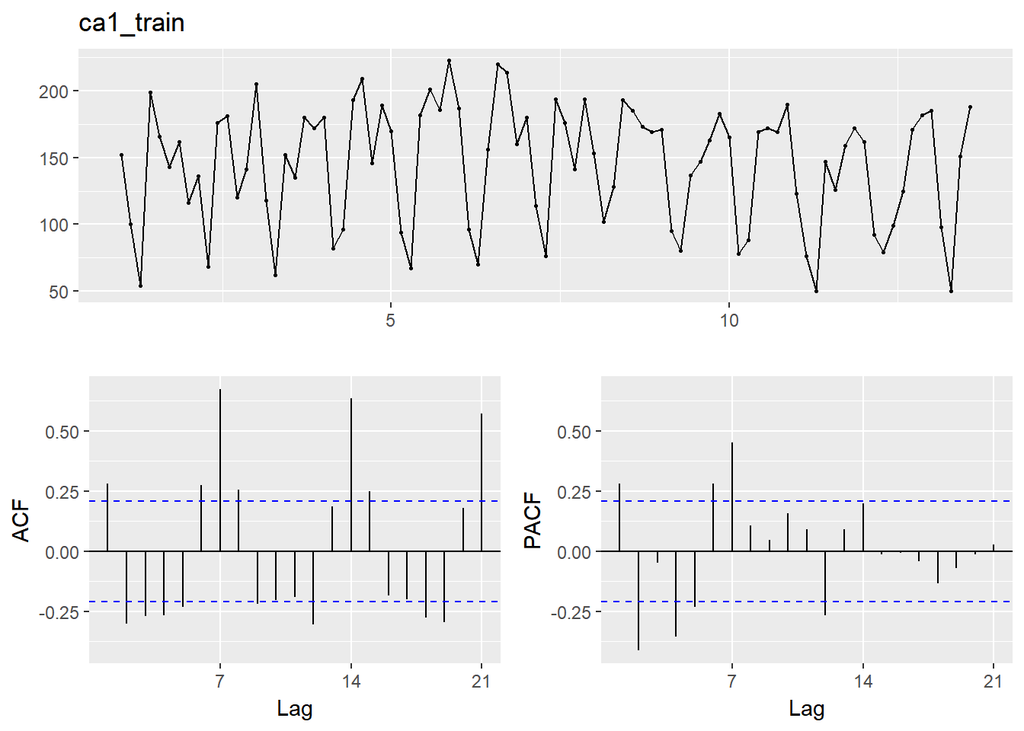

```r
ggtsdisplay(ca1_train)
```

To check the stationarity of the data, the ADF, PP, and KPSS tests are executed. And the results show that the CA1 train data is statistically stationary, which means we do not need to take any difference.

```r
adf.test(ca1_train)
```

```
##
##  Augmented Dickey-Fuller Test
##
## data:  ca1_train
## Dickey-Fuller = -7.7984, Lag order = 4, p-value = 0.01
## alternative hypothesis: stationary
```

```r
pp.test(ca1_train)
```

```
##
##  Phillips-Perron Unit Root Test
##
## data:  ca1_train
## Dickey-Fuller Z(alpha) = -52.779, Truncation lag parameter = 3,
## p-value = 0.01
## alternative hypothesis: stationary
```

```r
kpss.test(ca1_train)
```

```
##
##  KPSS Test for Level Stationarity
##
## data:  ca1_train
## KPSS Level = 0.1334, Truncation lag parameter = 2, p-value = 0.1
```

To make sure, we can use the $ndiffs$ function for the difference. The outcome also tells that taking a difference will not be neccessary.

```r
ndiffs(ca1_train)
```

```
## [1] 0
```

As observed in the CA1 graph that there might be the need to take a difference in terms of seaonality, we need to run the $OCSB$ test as below. However, the result, as opposed to our observation, indicates that we do not need any seasonal difference.

```r
nsdiffs(ca1_train, m = 7, test = "ocsb", max.D = 1)
```

```
## [1] 0
```

Under the circumstances that the $OCSB$ test result is totally at variance with the obervation, we can build models with and without a seaonal difference, which is the element $D = 1$ in the $auto.arima$ function.

```r
auto.arima(ca1_train, trace = TRUE, ic = 'bic')
```

```
##
##  ARIMA(2,0,2)(1,0,1)[7] with non-zero mean : Inf
##  ARIMA(0,0,0)           with non-zero mean : 938.4618
##  ARIMA(1,0,0)(1,0,0)[7] with non-zero mean : 883.1156
##  ARIMA(0,0,1)(0,0,1)[7] with non-zero mean : 908.7872
##  ARIMA(0,0,0)           with zero mean     : 1150.716
##  ARIMA(1,0,0)           with non-zero mean : 935.6631
##  ARIMA(1,0,0)(2,0,0)[7] with non-zero mean : 870.2813
##  ARIMA(1,0,0)(2,0,1)[7] with non-zero mean : Inf
##  ARIMA(0,0,0)(2,0,0)[7] with non-zero mean : 867.344
##  ARIMA(0,0,1)(2,0,0)[7] with non-zero mean : 869.8733
##  ARIMA(1,0,1)(2,0,0)[7] with non-zero mean : 874.0952
##  ARIMA(0,0,0)(2,0,0)[7] with zero mean     : Inf
##  ARIMA(0,0,0)(1,0,0)[7] with non-zero mean : 879.1726
##  ARIMA(0,0,0)(2,0,1)[7] with non-zero mean : Inf
##
##  Best model: ARIMA(0,0,0)(2,0,0)[7] with non-zero mean
```

```
## Series: ca1_train
## ARIMA(0,0,0)(2,0,0)[7] with non-zero mean
##
## Coefficients:
##         sar1    sar2      mean
##       0.4157  0.4341  141.2629
## s.e.  0.0951  0.0988   12.5993
##
## sigma^2 estimated as 769.9:  log likelihood=-424.69
## AIC=857.39   AICc=857.87   BIC=867.34
```

```r
auto.arima(ca1_train, trace = TRUE, D = 1, ic = 'bic')
```

```
##
##  ARIMA(2,0,2)(1,1,1)[7] with drift         : Inf
##  ARIMA(0,0,0)(0,1,0)[7] with drift         : 812.3871
##  ARIMA(1,0,0)(1,1,0)[7] with drift         : 797.7016
##  ARIMA(0,0,1)(0,1,1)[7] with drift         : 786.6812
##  ARIMA(0,0,0)(0,1,0)[7]                    : 808.0081
##  ARIMA(0,0,1)(1,1,1)[7] with drift         : 791.0856
##  ARIMA(0,0,1)(0,1,0)[7] with drift         : 816.6708
##  ARIMA(0,0,1)(0,1,2)[7] with drift         : 791.0858
##  ARIMA(0,0,1)(1,1,2)[7] with drift         : Inf
##  ARIMA(1,0,1)(0,1,1)[7] with drift         : 791.0616
##  ARIMA(0,0,0)(0,1,1)[7] with drift         : 785.0149
##  ARIMA(0,0,0)(0,1,1)[7]                    : 781.1482
##  ARIMA(0,0,0)(1,1,1)[7]                    : 785.3788
##  ARIMA(0,0,0)(0,1,2)[7]                    : 785.4227
##  ARIMA(0,0,0)(1,1,2)[7]                    : 789.9197
##  ARIMA(1,0,0)(0,1,1)[7]                    : 782.8503
##  ARIMA(0,0,1)(0,1,1)[7]                    : 782.7104
##  ARIMA(1,0,1)(0,1,1)[7]                    : 787.1072
##
##  Best model: ARIMA(0,0,0)(0,1,1)[7]
```

```
## Series: ca1_train
## ARIMA(0,0,0)(0,1,1)[7]
##
## Coefficients:
##          sma1
##       -0.7476
## s.e.   0.1199
##
## sigma^2 estimated as 680.8:  log likelihood=-386.17
## AIC=776.33   AICc=776.49   BIC=781.15
```

By using the $auto.arima$ function, we have the parameters for the 4 candidate models including the second best models as follows.

1. ARIMA(p=0,d=0,q=0)(P=2,D=0,Q=0)[7]: 867.344
2. ARIMA( 0, 0, 1)( 2, 0, 0)[7]: 869.8733
3. ARIMA( 0, 0, 0)( 0, 1, 1)[7]: 781.1482
4. ARIMA( 0, 0, 1)( 0, 1, 1)[7]: 782.7104

The parameters have been plugged in the $Arima$ function, and we can have the fourteen days forecast to be compared with the testset in order to calculate the accuracy for the best model selection.

```r
ca1_m1 <- Arima(ca1_train, order = c(0, 0, 0),
                seasonal = list(order = c(2, 0, 0), period = 7),
                include.drift = FALSE)
ca1_m1_FCST <- forecast(ca1_m1, h = 14)

ca1_m2 <- Arima(ca1_train, order = c(0, 0, 1),
                seasonal = list(order = c(2, 0, 0), period = 7),
                include.drift = FALSE)
ca1_m2_FCST <- forecast(ca1_m2, h = 14)

ca1_m3 <- Arima(ca1_train, order = c(0, 0, 0),
                seasonal = list(order = c(0, 1, 1), period = 7),
                include.drift = FALSE)
ca1_m3_FCST <- forecast(ca1_m3, h = 14)

ca1_m4 <- Arima(ca1_train, order = c(0, 0, 1),
                seasonal = list(order = c(0, 1, 1), period = 7),
                include.drift = FALSE)
ca1_m4_FCST <- forecast(ca1_m4, h = 14)
```

Just like the process in the first store, we need to verify if each model fits the data using residual analysis throughout the $Box.test$. As a result, p-values of the four models are above 0.05 which indicates the residuals of the models follows the white noise process. Therefore, we can use the four models to forecast the next fourteen days.

```r
Box.test(ca1_m1$residuals, lag = 20, type = "Ljung-Box", fitdf = 4)
```

```
##
##  Box-Ljung test
##
## data:  ca1_m1$residuals
## X-squared = 21.507, df = 16, p-value = 0.1598
```

```r
Box.test(ca1_m2$residuals, lag = 20, type = "Ljung-Box", fitdf = 4)
```

```
##
##  Box-Ljung test
##
## data:  ca1_m2$residuals
## X-squared = 20.416, df = 16, p-value = 0.2021
```

```r
Box.test(ca1_m3$residuals, lag = 20, type = "Ljung-Box", fitdf = 4)
```

```
##
##  Box-Ljung test
##
## data:  ca1_m3$residuals
## X-squared = 23.835, df = 16, p-value = 0.09318
```

```r
Box.test(ca1_m4$residuals, lag = 20, type = "Ljung-Box", fitdf = 4)
```

```
##
##  Box-Ljung test
##
## data:  ca1_m4$residuals
## X-squared = 15.771, df = 16, p-value = 0.4691
```

# 3. Store in New York 2 (ID: 20974)

To begin with, it is hard to argue that there is either a trend or seasonality by looking at the trend and seaonal factors in the below graphs separately.

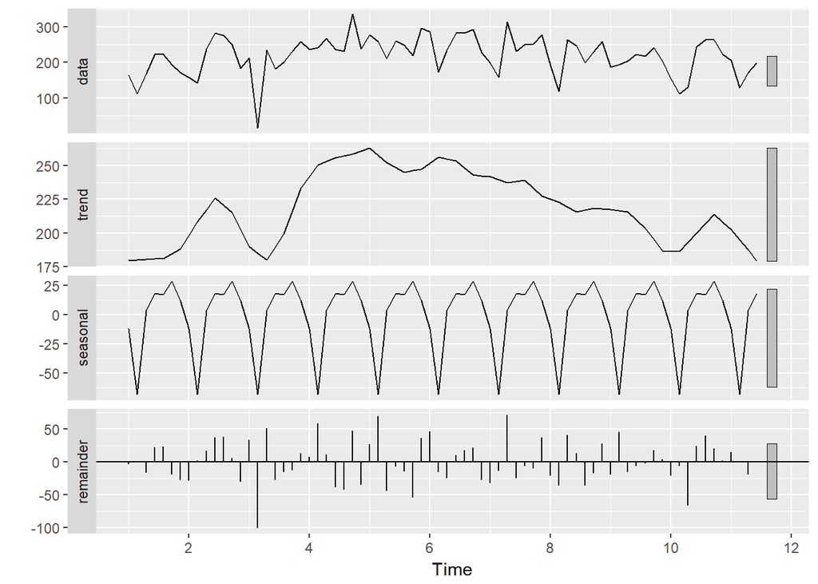

```r
ny2_train %>% stl(s.window = "period") %>% autoplot
```

## Q1. Holt Winter Analysis

The $ets$ function’s outcome is ETS(A, N, A), which indicates that the time series data has the chracteristics with the additive error type, no trend, and additive seaonality. And the Holt winter model has exponential smoothing with trend and additive seasonal component. As depicted below, the fitted values from the both models do not match up with the true value.

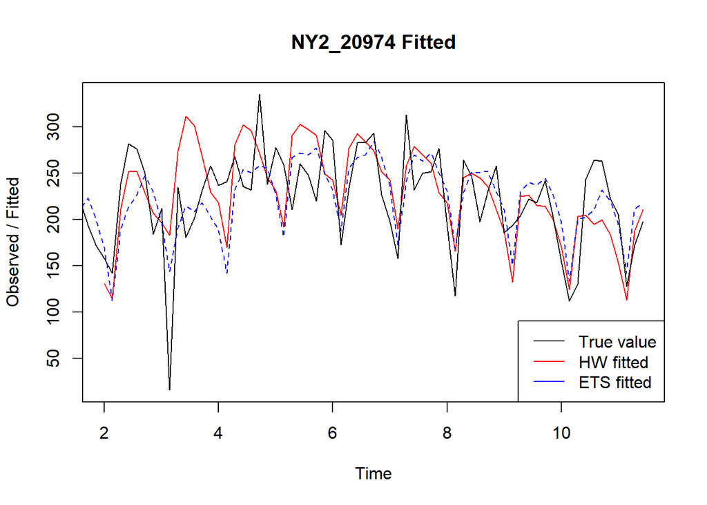

```r
ny2_train_ets <- ets(ny2_train, model = "ZZZ") #ETS(A, N, A)
ny2_train_HW <- HoltWinters(ny2_train)

ny2_train_ets_fcst <- forecast(ny2_train_ets, h = 14)
ny2_train_HW_fcst <- forecast(ny2_train_HW, h = 14)

plot(ny2_train_HW, main = "NY2_20974 Fitted")
lines(fitted(ny2_train_ets), col = "blue", lty = 2)
legend("bottomright",c("True value", "HW fitted", "ETS fitted"), lty = 1, col = c("black","red", "blue"))
```

When it comes to the prediction in the fourteen days, both models do not represent the true values of the lettuce demand well with the similiar pattern especially on the peak season.

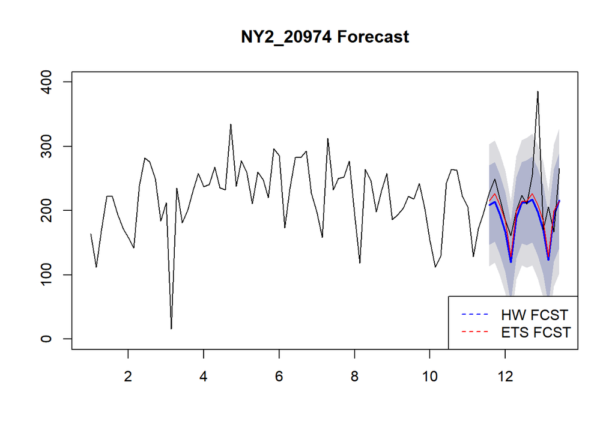

```r
ny2_train_ets_fcst <- forecast(ny2_train_ets, h = 14)
ny2_train_HW_fcst <- forecast(ny2_train_HW, h = 14)

plot(ny2_train_HW_fcst, ylim = c(0, 400), main = "NY2_20974 Forecast")
lines(ny2)
lines(ny2_train_ets_fcst$mean, col = "red")
legend("bottomright",c("HW FCST", "ETS FCST"), lty = 2, col = c("blue","red"))
```

## Q2. ARIMA Analysis

For the ARIMA modeling, we could take a look at the ACF and PACF firstly. It seems that the ACF values decreases exponentialy, whereas the values of the PACF has one spike on the first period. Therefore, we can assume that this could be the AR(1) model.

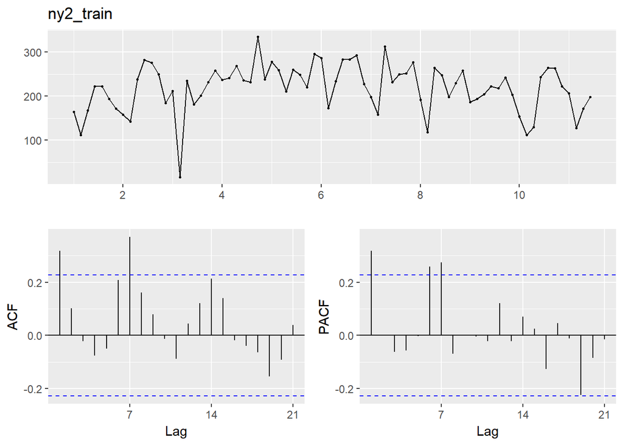

```r
ggtsdisplay(ny2_train)
```

To check the staionarity of the data, the three tests have been executed as below. The p-values from the tests points out that the data follows the staionarity.

```r
adf.test(ny2_train)
```

```
##
##  Augmented Dickey-Fuller Test
##
## data:  ny2_train
## Dickey-Fuller = -3.5721, Lag order = 4, p-value = 0.04182
## alternative hypothesis: stationary
```

```r
pp.test(ny2_train)
```

```
##
##  Phillips-Perron Unit Root Test
##
## data:  ny2_train
## Dickey-Fuller Z(alpha) = -48.35, Truncation lag parameter = 3,
## p-value = 0.01
## alternative hypothesis: stationary
```

```r
kpss.test(ny2_train)
```

```
##
##  KPSS Test for Level Stationarity
##
## data:  ny2_train
## KPSS Level = 0.3017, Truncation lag parameter = 1, p-value = 0.1
```

The $ndiffs$ function also indicates that it is unnecessary to take a difference of the data.

```r
ndiffs(ny2_train)
```

```
## [1] 0
```

When testing the $OCSB$ to check the need for the seaonal difference, we can see the result as 0, which points out the data is stationary in terms of seaonality. However, the seaonal difference is added to the $auto.arima$ function because we can observe some regular spike on the ACF chart.

```r
nsdiffs(ny2_train, m = 7, test = "ocsb", max.D = 1)
```

```
## [1] 0
```

First of all, based on the information criteria, we can compare the models with one another. On top of that, I added the D=1 in the $auto.arima$ function for the seasonal difference in a manual way. As long as we can use the computational power, it is better to generate the possible candidates.

```r
auto.arima(ny2_train, trace = TRUE, ic = 'bic')
```

```
##
##  ARIMA(2,0,2)(1,0,1)[7] with non-zero mean : Inf
##  ARIMA(0,0,0)           with non-zero mean : 807.7883
##  ARIMA(1,0,0)(1,0,0)[7] with non-zero mean : 799.672
##  ARIMA(0,0,1)(0,0,1)[7] with non-zero mean : 802.793
##  ARIMA(0,0,0)           with zero mean     : 1016.181
##  ARIMA(1,0,0)           with non-zero mean : 804.2108
##  ARIMA(1,0,0)(2,0,0)[7] with non-zero mean : 803.0404
##  ARIMA(1,0,0)(1,0,1)[7] with non-zero mean : Inf
##  ARIMA(1,0,0)(2,0,1)[7] with non-zero mean : Inf
##  ARIMA(0,0,0)(1,0,0)[7] with non-zero mean : 800.1286
##  ARIMA(2,0,0)(1,0,0)[7] with non-zero mean : 803.6119
##  ARIMA(1,0,1)(1,0,0)[7] with non-zero mean : 803.716
##  ARIMA(2,0,1)(1,0,0)[7] with non-zero mean : Inf
##  ARIMA(1,0,0)(1,0,0)[7] with zero mean     : 836.4228
##
##  Best model: ARIMA(1,0,0)(1,0,0)[7] with non-zero mean
```

```
## Series: ny2_train
## ARIMA(1,0,0)(1,0,0)[7] with non-zero mean
##
## Coefficients:
##          ar1    sar1      mean
##       0.2551  0.3472  216.2598
## s.e.  0.1147  0.1120   10.8359
##
## sigma^2 estimated as 2355:  log likelihood=-391.23
## AIC=790.46   AICc=791.04   BIC=799.67
```

```r
auto.arima(ny2_train, D = 1, trace = TRUE, ic = 'bic')
```

```
##
##  ARIMA(2,0,2)(1,1,1)[7] with drift         : Inf
##  ARIMA(0,0,0)(0,1,0)[7] with drift         : 744.6242
##  ARIMA(1,0,0)(1,1,0)[7] with drift         : 739.8838
##  ARIMA(0,0,1)(0,1,1)[7] with drift         : Inf
##  ARIMA(0,0,0)(0,1,0)[7]                    : 740.5898
##  ARIMA(1,0,0)(0,1,0)[7] with drift         : 747.4965
##  ARIMA(1,0,0)(2,1,0)[7] with drift         : 741.3997
##  ARIMA(1,0,0)(1,1,1)[7] with drift         : Inf
##  ARIMA(1,0,0)(2,1,1)[7] with drift         : Inf
##  ARIMA(0,0,0)(1,1,0)[7] with drift         : 737.209
##  ARIMA(0,0,1)(1,1,0)[7] with drift         : 740.1623
##  ARIMA(1,0,1)(1,1,0)[7] with drift         : 743.0943
##  ARIMA(0,0,0)(1,1,0)[7]                    : 733.0689
##  ARIMA(0,0,0)(2,1,0)[7]                    : 736.1013
##  ARIMA(0,0,0)(1,1,1)[7]                    : Inf
##  ARIMA(0,0,0)(2,1,1)[7]                    : Inf
##  ARIMA(1,0,0)(1,1,0)[7]                    : 735.7234
##  ARIMA(0,0,1)(1,1,0)[7]                    : 736.0071
##  ARIMA(1,0,1)(1,1,0)[7]                    : 741.4778
##
##  Best model: ARIMA(0,0,0)(1,1,0)[7]
```

```
## Series: ny2_train
## ARIMA(0,0,0)(1,1,0)[7]
##
## Coefficients:
##          sar1
##       -0.4004
## s.e.   0.1094
##
## sigma^2 estimated as 2907:  log likelihood=-362.33
## AIC=728.66   AICc=728.85   BIC=733.07
```

We have found the parameters p, d, q, P, D, and Q of the ARIMA models as below.

1. ARIMA(p=1,d=0,q=0)(P=1,D=0,Q=0)[7]: 799.672
2. ARIMA( 0, 0, 0)( 1, 0, 0)[7]: 800.1286
3. ARIMA( 0, 0, 0)( 1, 1, 0)[7]: 733.0689
4. ARIMA( 1, 0, 0)( 1, 1, 0)[7]: 735.7234

And the parameters have been plugged in the $Arima$ function to build the ARIMA models as below.

```r
ny2_m1 <- Arima(ny2_train, order = c(1, 0, 0),
                seasonal = list(order = c(1, 0, 0), period = 7),
                include.drift = FALSE)
ny2_m1_FCST <- forecast(ny2_m1, h = 14)

ny2_m2 <- Arima(ny2_train, order = c(0, 0, 0),
                seasonal = list(order = c(1, 0, 0), period = 7),
                include.drift = FALSE)
ny2_m2_FCST <- forecast(ny2_m2, h = 14)

ny2_m3 <- Arima(ny2_train, order = c(0, 0, 0),
                seasonal = list(order = c(1, 1, 0), period = 7),
                include.drift = FALSE)
ny2_m3_FCST <- forecast(ny2_m3, h = 14)

ny2_m4 <- Arima(ny2_train, order = c(1, 0, 0),
                seasonal = list(order = c(1, 1, 0), period = 7),
                include.drift = FALSE)
ny2_m4_FCST <- forecast(ny2_m4, h = 14)
```

Now, we need to check if each model follows the white noise process throughout the $Box.test$ as below. As a result, the residuals from the four models are independent of the time series data, which is equal to satisfying the white noise process.

```r
Box.test(ny2_m1$residuals, lag = 20, type = "Ljung-Box", fitdf = 4)
```

```
##
##  Box-Ljung test
##
## data:  ny2_m1$residuals
## X-squared = 14.325, df = 16, p-value = 0.5746
```

```r
Box.test(ny2_m2$residuals, lag = 20, type = "Ljung-Box", fitdf = 4)
```

```
##
##  Box-Ljung test
##
## data:  ny2_m2$residuals
## X-squared = 19.457, df = 16, p-value = 0.2457
```

```r
Box.test(ny2_m3$residuals, lag = 20, type = "Ljung-Box", fitdf = 4)
```

```
##
##  Box-Ljung test
##
## data:  ny2_m3$residuals
## X-squared = 23.252, df = 16, p-value = 0.1072
```

```r
Box.test(ny2_m4$residuals, lag = 20, type = "Ljung-Box", fitdf = 4)
```

```
##
##  Box-Ljung test
##
## data:  ny2_m4$residuals
## X-squared = 23.716, df = 16, p-value = 0.0959
```

# 4. Store in California 2 (ID: 4904)

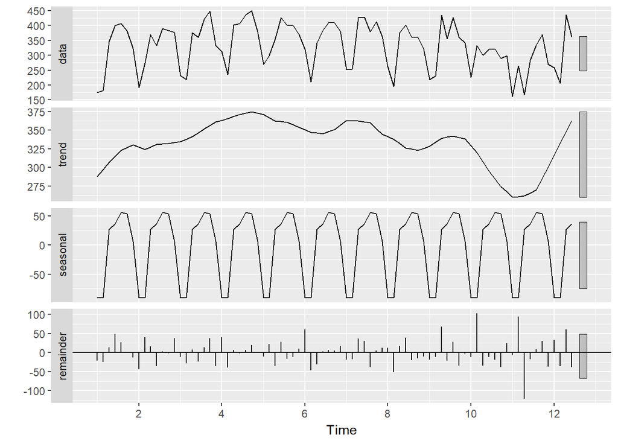

```r
ca2_train %>% stl(s.window = "period") %>% autoplot
```

## Q1. Holt Winters Analysis

To find out the parameters for the Holter Winters model, the $ets$ function has been executed. The outcome of the function shows that the time series data has the additive error type, no trend, and additive seaonality, which are represented as $ETS(A, N, A)$. And the Holt-Winters model has exponential smoothing with trend and additive seasonal component. As plotted below, the fitted values from the both models seems not only similiar but represent the true value well.

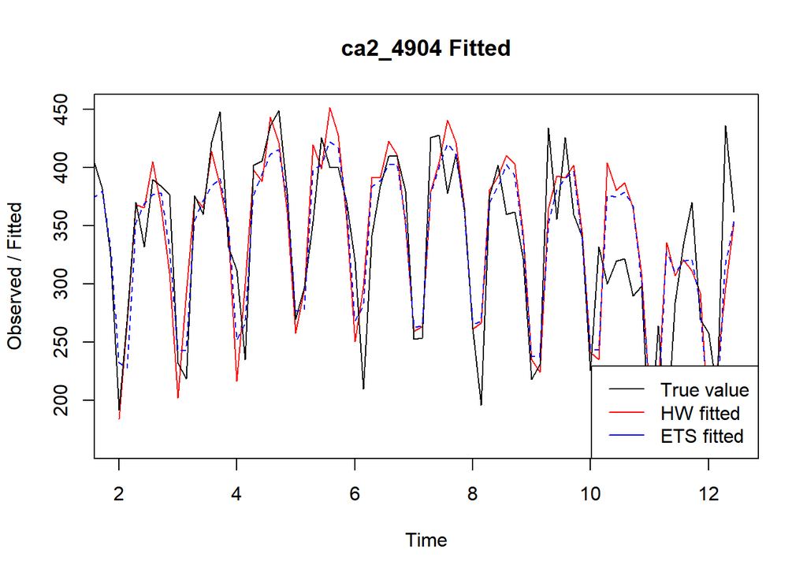

```r
ca2_train_ets <- ets(ca2_train, model = "ZZZ") #ETS(A, N, A)

ca2_train_HW <- HoltWinters(ca2_train)

ca2_train_ets_fcst <- forecast(ca2_train_ets, h = 14)
ca2_train_HW_fcst <- forecast(ca2_train_HW, h = 14)

plot(ca2_train_HW, main = "ca2_4904 Fitted")
lines(fitted(ca2_train_ets), col = "blue", lty = 2)
legend("bottomright",c("True value", "HW fitted", "ETS fitted"), lty = 1, col = c("black","red", "blue"))
```

For the prediction during the next fourteen days, both models represents the true values as plotted below. Both model seems similiar with a little differnce as a matter of the fact that the Holt Winters fits well with the upper spike and the ETS explains well for the lower spike.

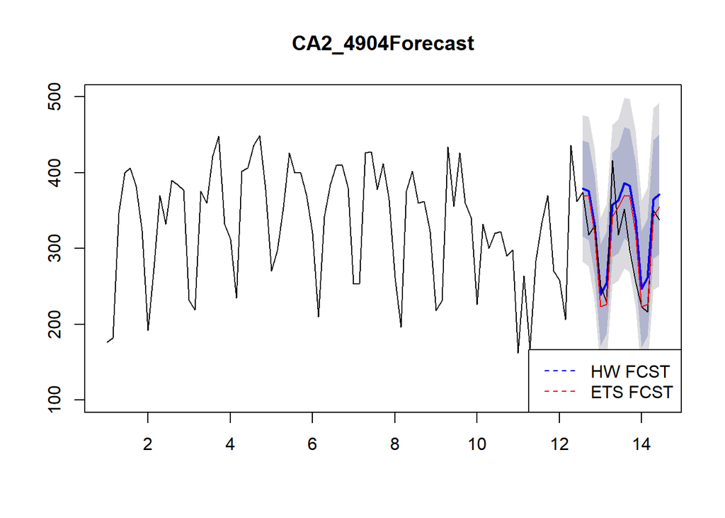

```r
ca2_train_ets_fcst <- forecast(ca2_train_ets, h = 14)
ca2_train_HW_fcst <- forecast(ca2_train_HW, h = 14)

plot(ca2_train_HW_fcst, ylim = c(100, 500), main = "CA2_4904Forecast")
lines(ca2)
lines(ca2_train_ets_fcst$mean, col = "red")
legend("bottomright",c("HW FCST", "ETS FCST"), lty = 2, col = c("blue","red"))
```

## Q2. ARIMA Analysis

According to the ACF, there is a significant seaonality factor observed by the regular spikes on 3, 7, 11, 14,18, and 21. In addition, the ACF and PACF decays exponentially, which we can assume the ARMA(1, 1) in the time series data.

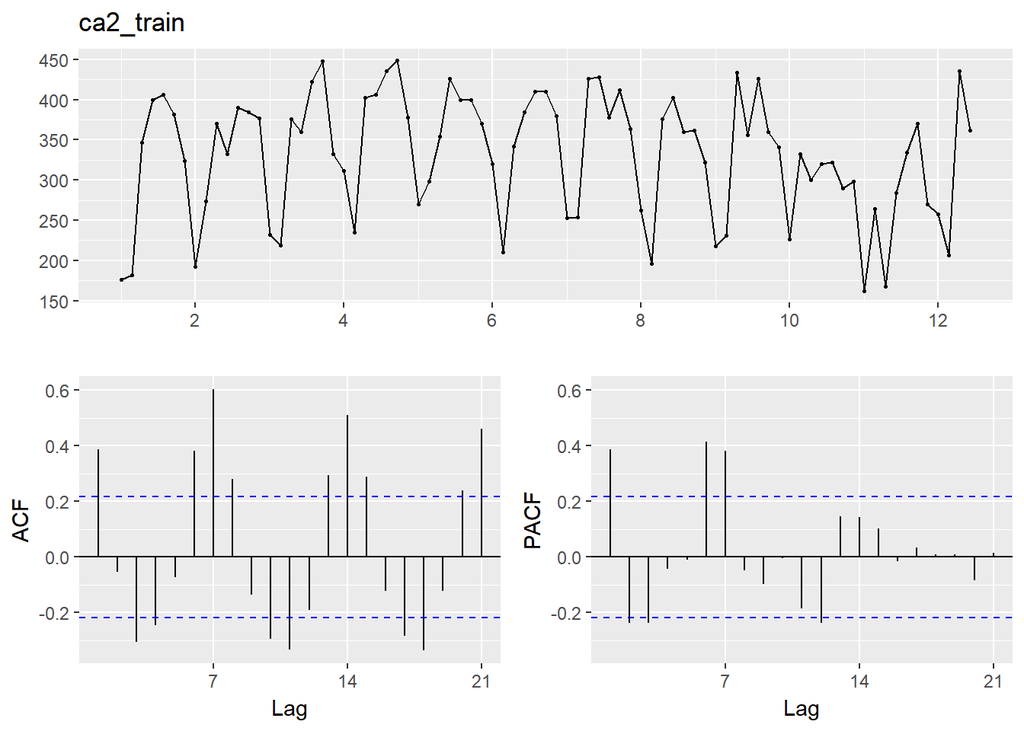

```r
ggtsdisplay(ca2_train)
```

To confirm that the time series data is stationary, we need to take the ADF, PP, and KPSS tests. The reuslts shows that the trainset is stationary, which means we do not need to take any difference in terms of non-seasonality.

```r
adf.test(ca2_train)
```

```
##
##  Augmented Dickey-Fuller Test
##
## data:  ca2_train
## Dickey-Fuller = -5.1903, Lag order = 4, p-value = 0.01
## alternative hypothesis: stationary
```

```r
pp.test(ca2_train)
```

```
##
##  Phillips-Perron Unit Root Test
##
## data:  ca2_train
## Dickey-Fuller Z(alpha) = -44.411, Truncation lag parameter = 3,
## p-value = 0.01
## alternative hypothesis: stationary
```

```r
kpss.test(ca2_train)
```

```
##
##  KPSS Test for Level Stationarity
##
## data:  ca2_train
## KPSS Level = 0.26506, Truncation lag parameter = 2, p-value = 0.1
```

However, when it comes to the stationarity in the seasonal part, the $OCSB$ test shows that we need to take the first order difference as we observed in the ACF plot.

```r
nsdiffs(ca2_train, m = 7, test = "ocsb", max.D = 1)
```

```
## [1] 1
```

Therefore, by using the $auto.arima$ function, we can conclude the best model on the information criteria as below.

```r
auto.arima(ca2_train, trace = TRUE, ic = 'bic')
```

```
##
##  ARIMA(2,0,2)(1,1,1)[7] with drift         : Inf
##  ARIMA(0,0,0)(0,1,0)[7] with drift         : 828.139
##  ARIMA(1,0,0)(1,1,0)[7] with drift         : 824.7688
##  ARIMA(0,0,1)(0,1,1)[7] with drift         : Inf
##  ARIMA(0,0,0)(0,1,0)[7]                    : 823.8362
##  ARIMA(0,0,0)(1,1,0)[7] with drift         : 820.5456
##  ARIMA(0,0,0)(1,1,1)[7] with drift         : Inf
##  ARIMA(0,0,0)(2,1,1)[7] with drift         : Inf
##  ARIMA(0,0,1)(1,1,0)[7] with drift         : 824.7956
##  ARIMA(1,0,1)(1,1,0)[7] with drift         : 826.3017
##  ARIMA(0,0,0)(1,1,0)[7]                    : 816.4742
##  ARIMA(0,0,0)(2,1,0)[7]                    : 814.8431
##  ARIMA(0,0,0)(2,1,1)[7]                    : Inf
##  ARIMA(1,0,0)(2,1,0)[7]                    : 817.9219
##  ARIMA(0,0,1)(2,1,0)[7]                    : 818.3788
##  ARIMA(1,0,1)(2,1,0)[7]                    : 815.9494
##  ARIMA(0,0,0)(2,1,0)[7] with drift         : 818.6229
##
##  Best model: ARIMA(0,0,0)(2,1,0)[7]
```

```
## Series: ca2_train
## ARIMA(0,0,0)(2,1,0)[7]
##
## Coefficients:
##          sar1     sar2
##       -0.5576  -0.3439
## s.e.   0.1296   0.1341
##
## sigma^2 estimated as 2936:  log likelihood=-400.97
## AIC=807.93   AICc=808.27   BIC=814.84
```

As a result of the $auto.arima$, we have the best and second best model as below.

1. ARIMA(p=0,d=0,q=0)(P=2,D=1,Q=0)[7]: 814.8431
2. ARIMA( 1, 0, 1)( 2, 1, 0)[7]: 815.9494

By using the function $Arima$ we can build the two model with the above parameters.

```r
ca2_m1 <- Arima(ca2_train, order = c(0, 0, 0),
                seasonal = list(order = c(2, 1, 0), period = 7),
                include.drift = FALSE)
ca2_m1_FCST <- forecast(ca2_m1, h = 14)

ca2_m2 <- Arima(ca2_train, order = c(1, 0, 1),
                seasonal = list(order = c(2, 1, 0), period = 7),
                include.drift = FALSE)
ca2_m2_FCST <- forecast(ca2_m2, h = 14)
```

The first model with the lowest information criteria does not follow the white noise by showing the p-value of the box test below 0.05. However, the p-value (0.08952) of the second model ARIMA(p=1,d=0,q=1)(P=2,D=1,Q=0) shows that we cannot reject the null hypothesis of following the white noise process. Therefore, the second model is only able to be used to predict the fourteen days.

```r
Box.test(ca2_m1$residuals, lag = 20, type = "Ljung-Box", fitdf = 4)
```

```
##
##  Box-Ljung test
##
## data:  ca2_m1$residuals
## X-squared = 33.456, df = 16, p-value = 0.006427
```

```r
Box.test(ca2_m2$residuals, lag = 20, type = "Ljung-Box", fitdf = 4)
```

```
##
##  Box-Ljung test
##
## data:  ca2_m2$residuals
## X-squared = 23.999, df = 16, p-value = 0.08952
```

# 5. Best Model Selection (Question3)

In the model selection, our goal is selecting the lowest error index in the testset and trainset, which indicates the best performance of the prediction in the fourteen days. In the NY_12631 times series, the fifth model built by $ets(ny1_train, model = "MNM")$ with alpha = 0.1106 and gamma = 1e-04 has the best performance.

```r
accuracy(ny1_m1_FCST, ny1_test)
```

```
##                      ME     RMSE      MAE       MPE     MAPE      MASE
## Training set  -3.105414 36.69961 27.74017 -2.939794 10.76798 0.7502288
## Test set     -20.148118 43.45155 37.18376 -9.614202 14.42021 1.0056294
##                    ACF1 Theil's U
## Training set 0.02290261        NA
## Test set     0.02730209 0.7079867
```

```r
accuracy(ny1_m2_FCST, ny1_test)
```

```
##                      ME     RMSE      MAE       MPE     MAPE      MASE
## Training set  -3.211743 36.72372 27.76791 -2.972695 10.78586 0.7509792
## Test set     -20.107711 43.41912 37.05857 -9.590493 14.37584 1.0022437
##                     ACF1 Theil's U
## Training set -0.01553457        NA
## Test set      0.02443076 0.7085131
```

```r
accuracy(ny1_m3_FCST, ny1_test)
```

```
##                      ME     RMSE      MAE        MPE     MAPE      MASE
## Training set   4.103944 40.24048 31.06843 -0.5328407 11.90586 0.8402411
## Test set     -12.488880 41.26388 37.45403 -6.8059927 14.08000 1.0129389
##                     ACF1 Theil's U
## Training set 0.057668088        NA
## Test set     0.009455242 0.6520634
```

```r
accuracy(ny1_m4_FCST, ny1_test)
```

```
##                      ME     RMSE      MAE        MPE     MAPE     MASE
## Training set   5.000866 41.67053 31.99411 -0.3315559 12.19249 0.865276
## Test set     -13.678146 48.20897 42.93832 -7.7253385 16.03808 1.161261
##                    ACF1 Theil's U
## Training set 0.07589908        NA
## Test set     0.15892653 0.7741603
```

```r
accuracy(ny1_train_ets_fcst, ny1_test)  #best model
```

```
##                     ME     RMSE      MAE        MPE     MAPE      MASE
## Training set  5.057772 35.80058 27.26714  0.3142787 10.32621 0.7374359
## Test set     -8.834295 40.60785 34.07671 -5.3104201 12.70419 0.9215997
##                    ACF1 Theil's U
## Training set 0.03667383        NA
## Test set     0.03405950 0.6638973
```

```r
accuracy(ny1_train_HW_fcst, ny1_test)
```

```
##                      ME     RMSE      MAE       MPE     MAPE      MASE
## Training set   4.339208 41.13698 32.44649 -0.421215 12.29562 0.8775107
## Test set     -13.750164 41.00034 35.38035 -7.043859 13.40080 0.9568566
##                    ACF1 Theil's U
## Training set 0.04916482        NA
## Test set     0.10932753 0.6583202
```

```r
accuracy(ca1_m1_FCST, ca1_test)
```

```
##                      ME     RMSE      MAE       MPE     MAPE      MASE
## Training set  0.5189584 27.27519 22.00279 -4.789475 17.49195 0.8272485
## Test set     10.0225859 42.74479 28.92968  3.156810 17.58525 1.0876818
##                   ACF1 Theil's U
## Training set 0.1248860        NA
## Test set     0.1833632 0.7259882
```

```r
accuracy(ca1_m2_FCST, ca1_test)
```

```
##                     ME     RMSE      MAE       MPE     MAPE      MASE
## Training set 0.4668163 27.01198 21.78555 -4.745626 17.30064 0.8190807
## Test set     9.2033537 43.34521 29.71731  2.468555 18.06543 1.1172946
##                     ACF1 Theil's U
## Training set -0.01288296        NA
## Test set      0.18297283 0.7303599
```

```r
accuracy(ca1_m3_FCST, ca1_test)
```

```
##                       ME     RMSE      MAE       MPE     MAPE      MASE
## Training set -0.06320554 24.89233 18.27833 -2.935965 13.78152 0.6872184
## Test set      8.67456799 41.49454 30.70063  3.132855 19.59288 1.1542648
##                   ACF1 Theil's U
## Training set 0.1811863        NA
## Test set     0.1803610 0.6557006
```

```r
accuracy(ca1_m4_FCST, ca1_test)
```

```
##                       ME     RMSE      MAE      MPE     MAPE      MASE
## Training set 0.002828693 24.33113 17.78837 -2.70520 13.37245 0.6687969
## Test set     7.493254846 41.08078 30.72942  2.31373 19.62275 1.1553471
##                     ACF1 Theil's U
## Training set 0.003568804        NA
## Test set     0.171116665 0.6433336
```

```r
accuracy(ca1_train_ets_fcst, ca1_test) #best model
```

```
##                      ME     RMSE      MAE       MPE     MAPE      MASE
## Training set -0.6145157 23.07634 18.50710 -3.515189 14.30259 0.6958194
## Test set     12.1034677 38.26867 27.96267  5.927577 18.01851 1.0513246
##                    ACF1 Theil's U
## Training set 0.08570827        NA
## Test set     0.07392921 0.6079273
```

```r
accuracy(ca1_train_HW_fcst, ca1_test)
```

```
##                     ME     RMSE      MAE       MPE     MAPE      MASE
## Training set  2.549639 26.96123 21.16340 -1.543417 15.64948 0.7956895
## Test set     13.814484 44.13612 32.22918  6.952435 20.79991 1.2117344
##                    ACF1 Theil's U
## Training set 0.06004512        NA
## Test set     0.21368226 0.7028117
```

In the NY_20974, the second model ARIMA(p=0,d=0,q=0)(P=1,D=0,Q=0) is selected to predict because the RMSE in the testset is the lowest among the others.

```r
accuracy(ny2_m1_FCST, ny2_test)
```

```
##                     ME     RMSE      MAE         MPE     MAPE      MASE
## Training set  1.254147 47.53160 37.97326 -17.7643380 32.56668 0.8099996
## Test set     10.036807 52.43042 31.68473   0.3087592 12.87230 0.6758601
##                     ACF1 Theil's U
## Training set -0.01901233        NA
## Test set     -0.12864521  0.747932
```

```r
accuracy(ny2_m2_FCST, ny2_test) #best model
```

```
##                    ME     RMSE      MAE         MPE     MAPE      MASE
## Training set 1.693013 49.00018 38.86495 -17.3347673 32.56742 0.8290200
## Test set     9.640632 52.05738 31.71132   0.2576871 12.83609 0.6764273
##                    ACF1 Theil's U
## Training set  0.2388830        NA
## Test set     -0.1584629 0.7412202
```

```r
accuracy(ny2_m3_FCST, ny2_test)
```

```
##                     ME     RMSE      MAE        MPE     MAPE      MASE
## Training set  2.653883 50.91499 38.41829 -10.632269 26.89086 0.8194923
## Test set     22.693110 56.56664 35.80596   8.241725 14.68606 0.7637692
##                    ACF1 Theil's U
## Training set  0.1489868        NA
## Test set     -0.2769070 0.8923463
```

```r
accuracy(ny2_m4_FCST, ny2_test)
```

```
##                     ME     RMSE      MAE        MPE     MAPE      MASE
## Training set  2.179798 50.32246 37.45314 -11.296628 27.01825 0.7989049
## Test set     23.426867 56.29901 35.09785   8.567396 14.36945 0.7486648
##                     ACF1 Theil's U
## Training set -0.01799129        NA
## Test set     -0.29204440 0.8898335
```

```r
accuracy(ny2_train_ets_fcst, ny2_test)
```

```
##                     ME     RMSE      MAE       MPE     MAPE      MASE
## Training set -0.391529 40.48805 33.38366 -12.74805 25.63071 0.7120996
## Test set     26.768579 56.18657 34.06088   9.25930 13.52027 0.7265454
##                     ACF1 Theil's U
## Training set  0.08495815        NA
## Test set     -0.32235890 0.8563258
```

```r
accuracy(ny2_train_HW_fcst, ny2_test)
```

```
##                     ME     RMSE      MAE       MPE     MAPE      MASE
## Training set -4.885523 48.33779 38.10070 -18.50064 32.08069 0.8127180
## Test set     35.325417 60.62725 39.24421  13.37705 15.68620 0.8371099
##                    ACF1 Theil's U
## Training set  0.2566881        NA
## Test set     -0.2667833 0.9234198
```

For the CA 4904, the first model $ets(ca2_train, model = "ANA")$ with alpha = 0.1951 and gamma = 1e-04 has the lowest RMSE, which indicates the best model to predict.

```r
accuracy(ca2_m2_FCST, ca2_test)
```

```
##                      ME     RMSE      MAE       MPE     MAPE      MASE
## Training set -0.5390384 48.12504 35.12393 -1.657746 11.85528 0.7458167
## Test set     -2.8671277 41.37553 33.59529 -2.535405 11.37570 0.7133577
##                    ACF1 Theil's U
## Training set -0.1212624        NA
## Test set     -0.3400886 0.5575332
```

```r
accuracy(ca2_train_ets_fcst, ca2_test)  #best Model
```

```
##                       ME     RMSE      MAE       MPE      MAPE      MASE
## Training set  -0.8150608 43.01756 32.41628 -2.416190 11.147762 0.6883227
## Test set     -10.2354038 38.17050 28.35945 -3.954536  9.195015 0.6021805
##                     ACF1 Theil's U
## Training set -0.06927149        NA
## Test set      0.11126015 0.4324828
```

```r
accuracy(ca2_train_HW_fcst, ca2_test)
```

```
##                      ME     RMSE      MAE       MPE     MAPE      MASE
## Training set  -4.767936 49.34754 35.89352  -3.28731 12.14680 0.7621579
## Test set     -27.358701 45.31409 37.38860 -10.16931 12.85045 0.7939043
##                    ACF1 Theil's U
## Training set -0.1177080        NA
## Test set      0.0797803 0.5061075
```

# 6. Forecast (Question 4)

Based on the model selection in the part 5, we can build a model with the time series datasets including the total period. By using the $forecast$ model, the predicted demand for the lettus has been saved in the “lettuce_forecast.csv”.

```r
CA1_46673 <- ets(ca1, model = "ANA", alpha = 0.0969 , gamma = 1e-04)
CA1_46673_FCST <- forecast(CA1_46673, h = 14)

CA2_4904 <- ets(ca2, model = "ANA", alpha = 0.1951 , gamma = 1e-04)
CA2_4904_FCST <- forecast(CA2_4904, h = 14)

NY1_12631 <- ets(ny1, model = "MNM", alpha = 0.1106 , gamma = 1e-04)
NY1_12631_FCST <- forecast(NY1_12631, h = 14)

NY2_20974 <- Arima(ny2, order = c(0, 0, 0),
                seasonal = list(order = c(1, 0, 0), period = 7),
                include.drift = FALSE)
NY2_20974_FCST <- forecast(NY2_20974, h = 14)

Store <- seq.Date(as.Date("2015-6-16"), as.Date("2015-6-29"), "day")

lettus_fcst <- data.frame(CA_46673 = round(CA1_46673_FCST$mean,0), CA_4904 = round(CA2_4904_FCST$mean,0), NY_12631 = round(NY1_12631_FCST$mean,0), NY_20974 =
round(NY2_20974_FCST$mean,0))

colnames(lettus_fcst) <- c("California 1 (ID:46673)",
                           "California 2 (ID:4904)",
                           "New York 1 (ID:12631)",
                           "New York 2 (ID:20974)")
forecast <- cbind(Store, lettus_fcst)

write.csv(forecast, file = "lettuce_forecast.csv", row.names = FALSE)
```